# ISOM356 Final Project: Book Constrictor

Group Members: Matthew Lee & Derick Yang

```python
from datascience import *
from datascience.predicates import are
import numpy as np
import matplotlib
matplotlib.use('Agg', warn=False)
%matplotlib inline
import matplotlib.pyplot as plots
plots.style.use('fivethirtyeight')
import warnings
warnings.simplefilter(action="ignore", category=FutureWarning)

from urllib.request import urlopen
import re
def read_url(url):
    return re.sub('\\s+', ' ', urlopen(url).read().decode())

import pandas as pd
from typing import Union, List, Set
from tokenizer import tokenize
from typing import Dict
from collections import Counter

from IPython.display import Image
from IPython.core.display import HTML
```

# Introduction and Goals

```python
Image(url= "https://www.davidbrassrarebooks.com/pictures/03954_2.jpg?v=1478033012",width=200, height=200)
```

[figure not shown]

For this project, we used Python to parse through the classic novels listed on gutenberg.org and broke down the novels into words and sentences. By using data table, graph and frequency counting, we aim to visualize the characters, emotion, tones, themes and plots of the novels through different Python packages. Two novels we picked were $\textit{the Adventures of Huckleberry Finn}$ and $\textit{the Adventures of Tom Sawyer}$ by Mark Twain. These two books are something that most of the American students have familiarity with and many American students probably had them as assigned readings in high school. The Python packages we used for this project were listed below:

- Urllib.request
- Numpy
- Pandas
- Tokenizer

```python
Image(url= "https://vignette.wikia.nocookie.net/tomsawyer/images/e/e1/Tom_Sawyer_%281st_Edition_Version%29.jpg/revision/latest?cb=20180831004151",width=200, height=200)
```

[figure not shown]

# I. URL Request

First we used urllib.request to call the html website page where the digital novels locate and stored them into a variable. After we got the whole content of the novels, we split the novels into chapters and built them into a dataframe.

## a. Tom Sawyer (1876)

```python
TS_url = 'http://www.gutenberg.org/files/74/74-0.txt'
TS_text = read_url(TS_url)
TS_chapters = TS_text.split('CHAPTER')[36:]
Table().with_column('Tom Sawyer Chapters',TS_chapters)
```

| Tom Sawyer Chapters |
| --- |
| I “TOM!” No answer. “TOM!” No answer. “What's gone with ... |
| II SATURDAY morning was come, and all the summer world ... |
| III TOM presented himself before Aunt Polly, who was si ... |
| IV THE sun rose upon a tranquil world, and beamed down ... |
| V ABOUT half-past ten the cracked bell of the small chu ... |
| VI MONDAY morning found Tom Sawyer miserable. Monday mo ... |
| VII THE harder Tom tried to fasten his mind on his book ... |
| VIII TOM dodged hither and thither through lanes until ... |
| IX AT half-past nine, that night, Tom and Sid were sent ... |
| X THE two boys flew on and on, toward the village, spee ... |

... (25 rows omitted)

## b. Huckleberry Finn (1885)

```python
HF_url = 'http://www.gutenberg.org/files/76/76-0.txt'
HF_text = read_url(HF_url)
HF_chapters = HF_text.split('CHAPTER')[44:]
Table().with_column('Huckleburry Finn',HF_chapters)
```

| Huckleburry Finn |
| --- |
| I. YOU don't know about me without you have read a book ... |
| II. WE went tiptoeing along a path amongst the trees ba ... |
| III. WELL, I got a good going-over in the morning from ... |
| IV. WELL, three or four months run along, and it was we ... |
| V. I had shut the door to. Then I turned around and the ... |
| VI. WELL, pretty soon the old man was up and around aga ... |
| VII. “GIT up! What you 'bout?” I opened my eyes and loo ... |
| VIII. THE sun was up so high when I waked that I judged ... |
| IX. I wanted to go and look at a place right about the ... |
| X. AFTER breakfast I wanted to talk about the dead man ... |

... (33 rows omitted)

The tables above give us the list of chapters in both $\textit{Tom Sawyer}$ and $\textit{Huckleberry Finn}$ . In each column, we have the chapter number and the first sentence of each chapter. $\textit{The Adventures of Tom Sawyer}$ has 35 chapters and $\textit{the Adventures of Huckleberry Finn}$ has 43 chapters.

# II. Sentence and Chapter Length Comparison

## a) Tom Sawyer Average Chapter Sentence Length

```python
wordcount=[s.count(" ") for s in TS_chapters]
periodcount=np.char.count(TS_chapters, '.')
exclamationcount=np.char.count(TS_chapters, '!')
questioncount=np.char.count(TS_chapters, '?')
SentenceNumber=periodcount+exclamationcount+questioncount

chars_periods_TS = Table().with_columns([
        'Tom Sawyer Chapter Length', wordcount,
        'Number of Sentences', SentenceNumber,
        'Sentence Length', wordcount/SentenceNumber])
chars_periods_TS
```

| Tom Sawyer Chapter Length | Number of Sentences | Sentence Length |
| --- | --- | --- |
| 2385 | 201 | 11.8657 |
| 1846 | 141 | 13.0922 |
| 2249 | 100 | 22.49 |
| 3378 | 163 | 20.7239 |
| 1914 | 63 | 30.381 |
| 3493 | 342 | 10.2135 |
| 1909 | 162 | 11.784 |
| 1740 | 110 | 15.8182 |
| 2130 | 199 | 10.7035 |
| 2035 | 184 | 11.0598 |

... (25 rows omitted)

## b) Huckleberry Finn Average Chapter Sentence Length

```python
wordcount=[s.count(" ") for s in HF_chapters]
periodcount=np.char.count(HF_chapters, '.')
exclamationcount=np.char.count(HF_chapters, '!')
questioncount=np.char.count(HF_chapters, '?')
SentenceNumber=periodcount+exclamationcount+questioncount

chars_periods_HF = Table().with_columns([
        'Huckberry Finn Chapter Length', wordcount,
        'Number of Sentences', SentenceNumber,
        'Sentence Length', wordcount/SentenceNumber])
chars_periods_HF
```

| Huckberry Finn Chapter Length | Number of Sentences | Sentence Length |
| --- | --- | --- |
| 1414 | 72 | 19.6389 |
| 2379 | 144 | 16.5208 |
| 1687 | 82 | 20.5732 |
| 1378 | 93 | 14.8172 |
| 1623 | 105 | 15.4571 |
| 2965 | 139 | 21.3309 |
| 2691 | 136 | 19.7868 |
| 4518 | 289 | 15.6332 |
| 1605 | 74 | 21.6892 |
| 1444 | 73 | 19.7808 |

... (33 rows omitted)

```python
TSSummary=pd.DataFrame(chars_periods_TS["Sentence Length"]).describe()
HFSummary=pd.DataFrame(chars_periods_HF["Sentence Length"]).describe()
CombinedSummary=pd.concat([TSSummary,HFSummary], axis=1, join='inner')
CombinedSummary.columns=["Tom Sawyer","Huckleberry Finn"]
CombinedSummary.round(2)
```

|  | Tom Sawyer | Huckleberry Finn |
| --- | --- | --- |
| count | 35.00 | 43.00 |
| mean | 15.38 | 18.50 |
| std | 4.68 | 3.34 |
| min | 9.16 | 11.04 |
| 25% | 11.82 | 15.85 |
| 50% | 14.38 | 19.00 |
| 75% | 17.89 | 21.35 |
| max | 30.38 | 24.90 |

The table above summarizes the general information of the average sentence length in both works. As we can see the average sentence length in $\textit{Huckleberry Finn}$ is longer than that in $\textit{Tom Sawyer}$. Meanwhile, the standard deviation of the sentence length decreased a lot from $\textit{Tom Sawyer}$ to $\textit{Huckleberry Finn}$, which somehow signified major change of writing style for Mark Twain in these nine years. The author switched from shorter sentence to longer sentence with more consistent writing style.

The average sentence length of $\textit{the Adventures of Tom Sawyer}$ corresponds to the statistic data we found in $\textit{Business Insider}$ (https://www.businessinsider.com/literature-statistics-2014-6). Although we didn't find any reference of average sentence length for $\textit{Adventures of Huckleberry Finn}$, the average length we got from this work is reasonably close to $\textit{Tom Sawyer}$ since these two works were finished by the same person.

## c) Distribution Comparison

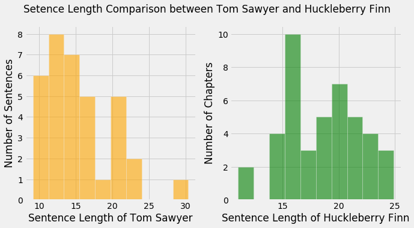

```python
plots.figure(figsize=(10,5))
plots.subplot(1,2,1)
plots.hist(chars_periods_TS['Sentence Length'],alpha=0.6,color='orange');
plots.xlabel("Sentence Length of Tom Sawyer")
plots.ylabel("Number of Sentences")
plots.subplot(1,2,2)
plots.hist(chars_periods_HF['Sentence Length'],alpha=0.6,color='green');
plots.xlabel("Sentence Length of Huckleberry Finn")
plots.ylabel("Number of Chapters")
plots.suptitle('Setence Length Comparison between Tom Sawyer and Huckleberry Finn');
```

# III. Charater Appearance

## a) Tom Sawyer Character Appearance Cumulative Frequency

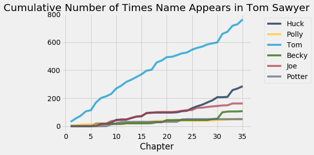

```python
TS_people = ['Huck','Polly', 'Tom','Becky','Joe','Potter']
TS_people_counts = {pp: np.char.count(TS_chapters, pp) for pp in TS_people}

counts = Table().with_columns([
        'Huck', TS_people_counts['Huck'],
        'Polly', TS_people_counts['Polly'],
        'Tom', TS_people_counts['Tom'],
        'Becky', TS_people_counts['Becky'],
        'Joe', TS_people_counts['Joe'],
        'Potter', TS_people_counts['Potter'],
    ])

cum_counts = counts.cumsum().with_column('Chapter', np.arange(1, 36, 1))
cum_counts.plot(column_for_xticks=6)
plots.title('Cumulative Number of Times Name Appears in Tom Sawyer');
```

The first thing our code reminded us of is that Mark Twain wrote $\textit{Tom Sawyer}$ in the third person. Rather than speaking from Tom’s point of view, Mark Twain wrote as the narrator of Tom’s life. It is due to the fact that Tom’s name appears so often and so consistently throughout the book. As our graph shows, Tom appears more than twice as often as Huck does, whose name appears second most. This is ultimately because the book is primarily about Tom’s life, and Huck is mainly along for the journey with Tom. What stood out to us, and validated the accuracy of our code, was when it showed a sudden jump in the number of times Becky’s name appears in the book starting after Chapter 30. This is because, as you may remember, it is around this time that Tom takes Becky to the cave. Before this instance, the only other time Becky is frequently mentioned is when Tom tries to impress her at the church in the beginning of the story.

## b) Huckleberry Finn Character Appearance Cumulative Frequency

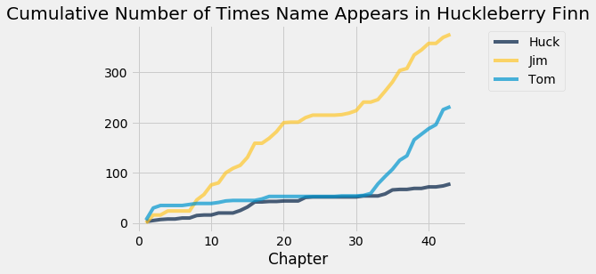

```python
HF_people = ['Huck','Jim', 'Tom']
HF_people_counts = {pp: np.char.count(HF_chapters, pp) for pp in HF_people}

counts = Table().with_columns([
        'Huck', HF_people_counts['Huck'],
        'Jim', HF_people_counts['Jim'],
        'Tom', HF_people_counts['Tom'],
    ])

cum_counts = counts.cumsum().with_column('Chapter', np.arange(1, 44, 1))
cum_counts.plot(column_for_xticks=3)
plots.title('Cumulative Number of Times Name Appears in Huckleberry Finn');
```

Running $\textit{Huckleberry Finn}$ through our code once again validated the accuracy of our code. This book is primarily about how Huck tries to help the slave Jim escape from his Master. This is due to the fact that his Master plans on selling him in an auction further down south, which would separate him from his family. Given this, it makes sense that Jim’s name appears so many times. Another thing worth noting is that unlike $\textit{Tom Sawyer}$, $\textit{Huckleberry Finn}$ is not written in the third person. It is due to this fact that Huck’s name does not appear very frequently. Our graph proves this point. Between Tom, Huck, and Jim, Huck’s name appears the least amount of times.

# IV. Emotion Words and Story Plot

One question we had was why Mark Twain used different styles of writing between $\textit{Tom Sawyer}$ and $\textit{Huckleberry Finn}$. We hypothesize that this is due to the fact that Mark Twain didn’t expect $\textit{Tom Sawyer}$ to be such a huge success. In his former work, Mark Twain flippantly refers to himself as the narrator throughout the book. In fact, through the guise of the narrator, he even compliments himself. This fact shows us that he took the writing of $\textit{Tom Sawyer}$ not as seriously as he took $\textit{Huckleberry Finn}$. Most likely, after seeing the massive success of his first work, he took the writing of $\textit{Huckleberry Finn}$ much more seriously.

## a) Tom Sawyer Cumulative Number of Emotion Words

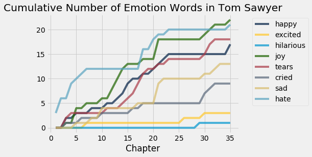

```python
TS_emotion = ['happy','excited','hilarious','joy','tears','cried','sad','hate']
TS_emotion_counts = {pp: np.char.count(TS_chapters, pp) for pp in TS_emotion}

counts = Table().with_columns([
        'happy', TS_emotion_counts['happy'],
        'excited', TS_emotion_counts['excited'],
        'hilarious', TS_emotion_counts['hilarious'],
        'joy', TS_emotion_counts['joy'],
        'tears', TS_emotion_counts['tears'],
        'cried', TS_emotion_counts['cried'],
        'sad', TS_emotion_counts['sad'],
        'hate', TS_emotion_counts['hate']
    ])

cum_counts = counts.cumsum().with_column('Chapter', np.arange(1, 36, 1))
cum_counts.plot(column_for_xticks=8)
plots.title('Cumulative Number of Emotion Words in Tom Sawyer');
```

## b) Huckleberry Finn Cumulative Number of Emotion Words

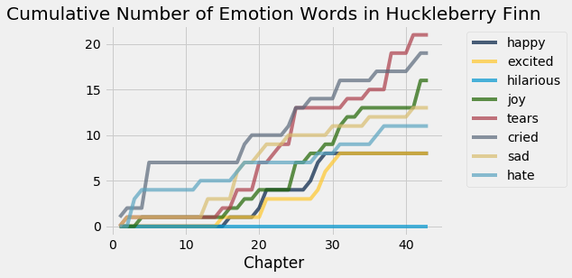

```python
HF_emotion = ['happy','excited','hilarious','joy','tears','cried','sad','hate']
HF_emotion_counts = {pp: np.char.count(HF_chapters, pp) for pp in HF_emotion}

counts = Table().with_columns([
        'happy', HF_emotion_counts['happy'],
        'excited', HF_emotion_counts['excited'],
        'hilarious', HF_emotion_counts['hilarious'],
        'joy', HF_emotion_counts['joy'],
        'tears', HF_emotion_counts['tears'],
        'cried', HF_emotion_counts['cried'],
        'sad', HF_emotion_counts['sad'],
        'hate', HF_emotion_counts['hate']
    ])

cum_counts = counts.cumsum().with_column('Chapter', np.arange(1, 44, 1))
cum_counts.plot(column_for_xticks=8)
plots.title('Cumulative Number of Emotion Words in Huckleberry Finn');
```

$\textit{Huckleberry Finn}$ stands in direct contrast to $\textit{Tom Sawyer}$ in terms of its mood despite it having similar characters. The two most often used words are “tears” and “cried” which have dominated the graph. Ultimately, $\textit{Huckleberry Finn}$ is a story about a young boy on a journey to free a slave he becomes friends with. This is not a happy story despite there being much adventure involved. It is due to this reason that $\textit{Huckleberry Finn}$ is by and large a more solemn book than $\textit{Tom Sawyer}$ is.

## IV. Word Tokenization

After having analyzed the general emotion mood in both works, we wished to delve into these two books more specifically by doing word and special character analysis to explore more interesting patterns.

The Tokenizer package gave us the ability to break down one sentence into words or special characters. Here, we built a function called tok(), which can break down the whole novel into separate words and special characters. We then used counter() function to count the number of frequency of each word or character apperance and rank them in descending order. We selected out the top 30 most frequent characters and words and further plotted them into bar charts for convenient comparison.

```python
def tok(text: str) -> Union[List[str], Set[str], Dict[str, int]]:
        return Counter([t.txt for t in tokenize(text) if t.txt])
```

## a) Most Frequent Word and Character in Tom Sawyer

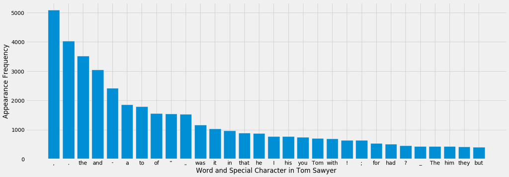

```python
TS=tok(TS_text)
temp={}
for k, v in sorted(TS.items(), key=lambda x: x[1], reverse=True)[:30]:
    temp[k]=v

plots.figure(figsize=(20,7))
plots.bar(range(len(temp)), list(temp.values()), align='center')
plots.xticks(range(len(temp)), list(temp.keys()))
plots.xlabel("Word and Special Character in Tom Sawyer")
plots.ylabel("Appearance Frequency")
plots.show()
```

## b) Most Frequent Word and Character in Huckleberry Finn

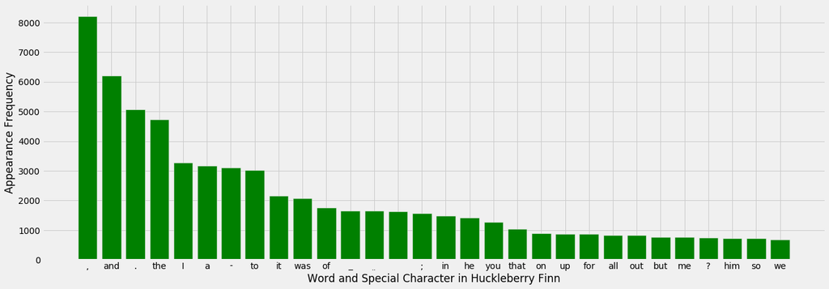

```python
HF=tok(HF_text)
temp={}
for k, v in sorted(HF.items(), key=lambda x: x[1], reverse=True)[:30]:
    temp[k]=v

plots.figure(figsize=(20,7))
plots.bar(range(len(temp)), list(temp.values()), align='center',color='green')
plots.xticks(range(len(temp)), list(temp.keys()))
plots.xlabel("Word and Special Character in Huckleberry Finn")
plots.ylabel("Appearance Frequency")
plots.show()
```

In $\textit{Tom Sawyer}$, there are not as many punctuation marks as those are used in $\textit{Huckleberry Finn}$. This is because the former was written in the third person's perspective, and name must be used when addressing characters and other major facets of the book. Since $\textit{Huckleberry Finn}$ was written through Huck’s perspective, there should be more punctuation marks than in a book that wasn’t written in the first person. Also, it is interesting that commas are much more common in $\textit{Huckleberry Finn}$ than in $\textit{Tom Sawyer}$. This is due to the fact that $\textit{Huckleberry Finn}$ is about two characters, Jim and Huck, whereas $\textit{Tom Sawyer}$ is largely about one character.

## c) Most Frequent Word in Huckberry Finn not in Tom Sawyer

For this part, we created two lists to store the words and characters appeared in each novel.

```python
TS_List=[]
for i in TS.items():
    TS_List.append(i[0])

HF_List=[]
for i in HF.items():
    HF_List.append(i[0])
```

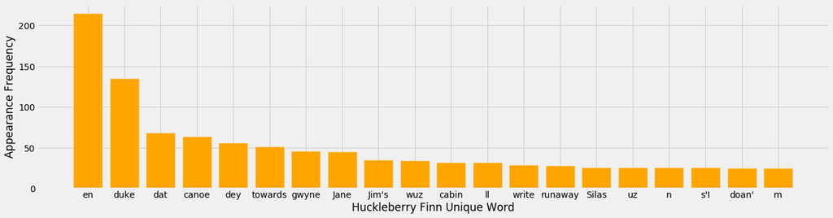

```python
HF_Only={}
for i in HF.items():
    if i[0] not in TS_List:
        HF_Only[i[0]]=i[1]

temp={}
for k, v in sorted(HF_Only.items(), key=lambda x: x[1], reverse=True)[:20]:
    temp[k]=v

plots.figure(figsize=(20,5))
plots.bar(range(len(temp)), list(temp.values()), align='center',color='orange')
plots.xticks(range(len(temp)), list(temp.keys()))
plots.xlabel("Huckleberry Finn Unique Word")
plots.ylabel("Appearance Frequency")
plots.show()
```

## d) Most Frequent Word in Tom Sawyer not in Huckleberry Finn

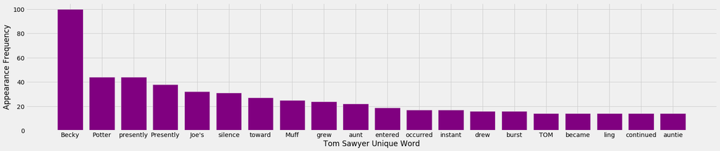

```python
TS_Only={}
for i in TS.items():
    if i[0] not in HF_List:
        TS_Only[i[0]]=i[1]

temp={}
for k, v in sorted(TS_Only.items(), key=lambda x: x[1], reverse=True)[:20]:
    temp[k]=v

plots.figure(figsize=(25,5))
plots.bar(range(len(temp)), list(temp.values()), align='center',color='purple')
plots.xticks(range(len(temp)), list(temp.keys()))
plots.xlabel("Tom Sawyer Unique Word")
plots.ylabel("Appearance Frequency")
plots.show()
```

# Conclusion

Python can give us the ability to break down classic literature work into words, summarize them into data and further visualize the data into comprehensible graphs. Based on these graphs, we can explore some plot patterns and author's writing patterns which won't be observed solely based on reading the books themselves. We were able to find very interesting trends throughout these two books by using codes to jump out of the box. It is entertaining to explore the similarities and differences between $\textit{Tom Sawyer}$ and $\textit{Huckleberry Finn}$, especially because they are both written by the same author.The same process and logic can also be applied to analyze a series of books written by same author to examine the change of his or her writing style along the time or to analyze similar novels belonging to same genre. We feel very excited to potentially expand on our code in the future to help us analyze books for both work and leisure.